# Data Exploration Part 1

# Business Question 1: Does the weather effectively influence the flights departure delays?

```r
library(tidyverse)
library(GGally)
```

```r
#flights_weather <- read_csv(here::here("cleaned_data/flights_weather.csv"))
tight_flights_weather <- read_csv(here::here("cleaned_data/tight_flights_weather.csv"))
```

```r
skimr::skim(tight_flights_weather)
```

```
── Data Summary ────────────────────────
                           Values
Name                       tight_flights_weather
Number of rows             291851
Number of columns          19
_______________________
Column type frequency:
  character                6
  numeric                  12
  POSIXct                  1
________________________
Group variables            None
```

|  | skim_variable | n_missing | complete_rate | min | max | empty | n_unique | whitespace |
| --- | --- | --- | --- | --- | --- | --- | --- | --- |
| 1 | carrier | 0 | 1 | 2 | 2 | 0 | 12 | 0 |
| 2 | tailnum | 0 | 1 | 5 | 6 | 0 | 4119 | 0 |
| 3 | origin | 0 | 1 | 3 | 3 | 0 | 3 | 0 |
| 4 | dest | 0 | 1 | 3 | 3 | 0 | 109 | 0 |
| 5 | wind_speed_group | 0 | 1 | 5 | 7 | 0 | 4 | 0 |
| 6 | visib_group | 0 | 1 | 5 | 14 | 0 | 4 | 0 |

|  | skim_variable | n_missing | complete_rate | mean | sd | p0 | p25 | p50 | p75 | p100 | hist |
| --- | --- | --- | --- | --- | --- | --- | --- | --- | --- | --- | --- |
| 1 | dep_delay | 0 | 1.0000000 | 15.183751 | 52.141573 | -84.00 | -6.000000 | -2.00000 | 12.00000 | 1548.00000 | ▇▁▁▁▁ |
| 2 | arr_delay | 1031 | 0.9964674 | 7.115446 | 55.427592 | -98.00 | -20.000000 | -7.00000 | 13.00000 | 1589.00000 | ▇▁▁▁▁ |
| 3 | flight | 0 | 1.0000000 | 1688.730541 | 1453.366306 | 1.00 | 518.000000 | 1332.00000 | 2230.00000 | 6988.00000 | ▇▅▁▁▁ |
| 4 | air_time | 1031 | 0.9964674 | 164.427116 | 97.846936 | 20.00 | 99.000000 | 139.00000 | 211.00000 | 712.00000 | ▇▂▂▁▁ |
| 5 | distance | 0 | 1.0000000 | 1161.249360 | 763.318484 | 93.00 | 636.000000 | 1005.00000 | 1598.00000 | 4983.00000 | ▇▃▂▁▁ |
| 6 | wind_dir | 0 | 1.0000000 | 185.578363 | 111.602038 | 0.00 | 75.365854 | 200.00000 | 280.00000 | 360.00000 | ▇▃▆▇▇ |
| 7 | wind_speed | 0 | 1.0000000 | 9.328300 | 4.738362 | 0.00 | 5.753900 | 9.20624 | 12.65858 | 32.22184 | ▅▇▂▁▁ |
| 8 | wind_gust | 0 | 1.0000000 | 10.734821 | 5.452812 | 0.00 | 6.621473 | 10.59436 | 14.56724 | 37.08025 | ▅▇▂▁▁ |
| 9 | visib | 0 | 1.0000000 | 9.371928 | 1.853584 | 0.12 | 10.000000 | 10.00000 | 10.00000 | 10.00000 | ▁▁▁▁▇ |
| 10 | month | 0 | 1.0000000 | 6.549911 | 3.395626 | 1.00 | 4.000000 | 7.00000 | 9.00000 | 12.00000 | ▇▆▆▆▇ |

[output cut: 2 more lines]

|  | skim_variable | n_missing | complete_rate | min | max | median | n_unique |
| --- | --- | --- | --- | --- | --- | --- | --- |
| 1 | time_hour | 0 | 1 | 2017-01-01 08:00:00 | 2017-12-31 07:00:00 | 2017-07-03 11:00:00 | 6757 |

```r
tight_flights_weather %>%
  filter(!is.na(arr_delay)) %>%
  summarise(cor(dep_delay, arr_delay))
```

| cor(dep_delay, arr_delay) |
| --- |
| 0.9411317 |

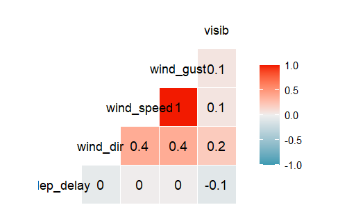

```r
tight_flights_weather %>%
  select(dep_delay, wind_dir, wind_speed, wind_gust, visib) %>%
  ggcorr(label = TRUE)
```

At a first sight, looking at the correlation indexes, it seems that there is not so much interaction between `dep_delays` and `weather` conditions.

I also notice that there is a very strong correlation between `wind speed` and `wind gust speed` for this reason, I could consider to delete one of the two since their relationship is so strong.

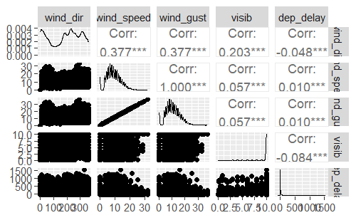

```r
tight_flights_weather %>%
  select(wind_dir, wind_speed, wind_gust, visib, dep_delay) %>%
  ggpairs(progress = FALSE)
```

It seems interesting to analyse the relationship that `dep_delays` has with `wind_dir` and `visibility`.

[figure not shown]

```r
tight_flights_weather %>%
  group_by(month) %>%
  summarise(mean_dep_delay = mean(dep_delay, na.rm = TRUE)) %>%
  ggplot()+
  aes(x = month, y = mean_dep_delay)+
  geom_col(fill = "9900FF")+
  scale_x_continuous(n.breaks = 12)+
  labs(
    x = "\nmonths",
    y = "departure delays mean (in mins)\n",
    title = "\nDeparture delays per month in 2017\n"
  )+
  theme_light()
```

# Wind Speed

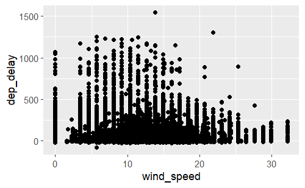

```r
tight_flights_weather %>%
  ggplot()+
  aes(x = wind_speed, y = dep_delay)+
  geom_point()
```

From this plot it seems that the `wind_speed` is more related maybe to the number of delays than to their length, but I am not actually interested in that, since I decided to concentrate on their length.

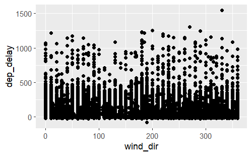

```r
tight_flights_weather %>%
  ggplot()+
  aes(x = wind_dir, y = dep_delay)+
  geom_point()
```

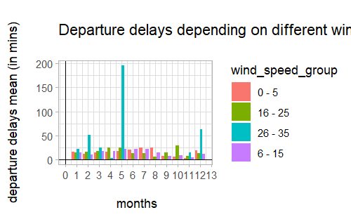

```r
tight_flights_weather %>%
  group_by(month, wind_speed_group) %>%
  summarise(mean_dep_delay = mean(dep_delay, na.rm = TRUE)) %>%
  ggplot()+
  aes(x = month, y = mean_dep_delay, fill = wind_speed_group)+
  geom_col(position = "dodge")+
  #geom_line() +
  geom_vline(xintercept = 0) +
  geom_hline(yintercept = 0) +
  theme_light()+
  labs(
    x = "\n months",
    y = "departure delays mean (in mins)\n",
    title = "\nDeparture delays depending on different wind speed conditions\n"
  )+
  scale_x_continuous(n.breaks = 12)
```

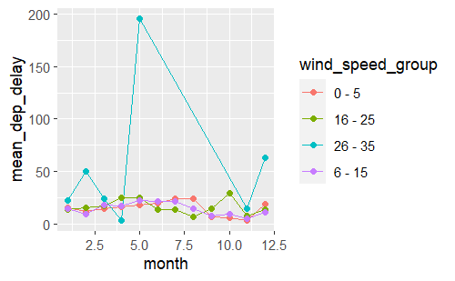

```r
tight_flights_weather %>%
  group_by(month, wind_speed_group) %>%
  summarise(mean_dep_delay = mean(dep_delay, na.rm = TRUE)) %>%
  ggplot()+
  aes(x = month, y = mean_dep_delay, colour = wind_speed_group)+
  #geom_col(position = "dodge")+
  geom_line()+
  geom_point()
```

However, looking with more attention at the above plot, we can notice that, at least, month by month it seems that the length of the delays increase when the wind speed is particularly high (look at May) even if even this proportion doesn’t seems to be regular.

[figure not shown]

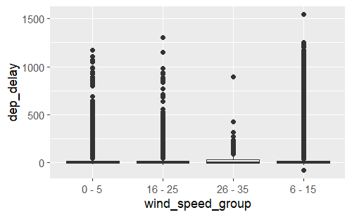

```r
tight_flights_weather %>%
  ggplot()+
  aes(x = wind_speed_group, y = dep_delay)+
  geom_boxplot()
```

```r
model <- lm(dep_delay ~ wind_speed_group, tight_flights_weather)
summary(model)
```

```
Call:
lm(formula = dep_delay ~ wind_speed_group, data = tight_flights_weather)

Residuals:
    Min      1Q  Median      3Q     Max
 -98.78  -20.78  -17.12   -3.78 1533.22

Coefficients:
                        Estimate Std. Error t value Pr(>|t|)
(Intercept)              15.5234     0.2262  68.614  < 2e-16 ***
wind_speed_group16 - 25   1.5919     0.3771   4.221 2.43e-05 ***
wind_speed_group26 - 35  11.1407     2.0589   5.411 6.27e-08 ***
wind_speed_group6 - 15   -0.7389     0.2535  -2.915  0.00355 **
---
Signif. codes:  0 ‘***’ 0.001 ‘**’ 0.01 ‘*’ 0.05 ‘.’ 0.1 ‘ ’ 1

Residual standard error: 52.13 on 291847 degrees of freedom
Multiple R-squared:  0.0002978, Adjusted R-squared:  0.0002875
F-statistic: 28.97 on 3 and 291847 DF,  p-value: < 2.2e-16
```

## Visib

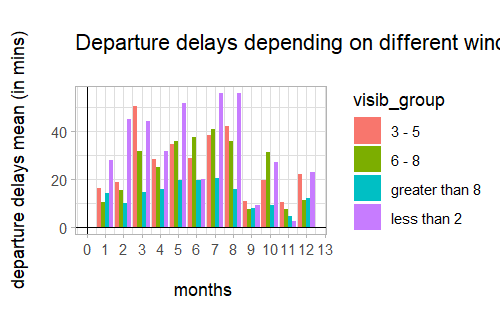

```r
tight_flights_weather %>%
  group_by(month, visib_group) %>%
  summarise(mean_dep_delay = mean(dep_delay, na.rm = TRUE)) %>%
  ggplot()+
  aes(x = month, y = mean_dep_delay, fill = visib_group)+
  geom_col(position = "dodge")+
  #geom_line() +
  geom_vline(xintercept = 0) +
  geom_hline(yintercept = 0) +
  theme_light()+
  labs(
    x = "\n months",
    y = "departure delays mean (in mins)\n",
    title = "\nDeparture delays depending on different wind speed conditions\n"
  )+
  scale_x_continuous(n.breaks = 12)
```

It seems that the visibility can be considered as a better parameter for measuring the departure delays than the wind speed.

However, since we saw that the correlation coefficient is still very low, we can deduce that even if its true that in mean less visibility is in some way proportional to the length of delays it cannot be considered as a significant parameter.

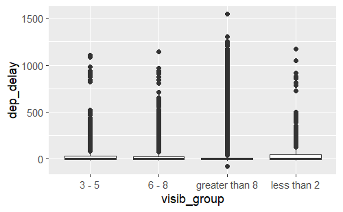

```r
tight_flights_weather %>%
  ggplot()+
  aes(x = visib_group, y = dep_delay)+
  geom_boxplot()
```

```r
tight_flights_weather %>%
  distinct(wind_dir)
```

| wind_dir |
| --- |
| 10.00000 |
| 360.00000 |
| 350.00000 |
| 20.00000 |
| 40.00000 |
| 70.00000 |
| 30.00000 |
| 340.00000 |
| 50.00000 |
| 290.00000 |

[output cut: 567 more lines]

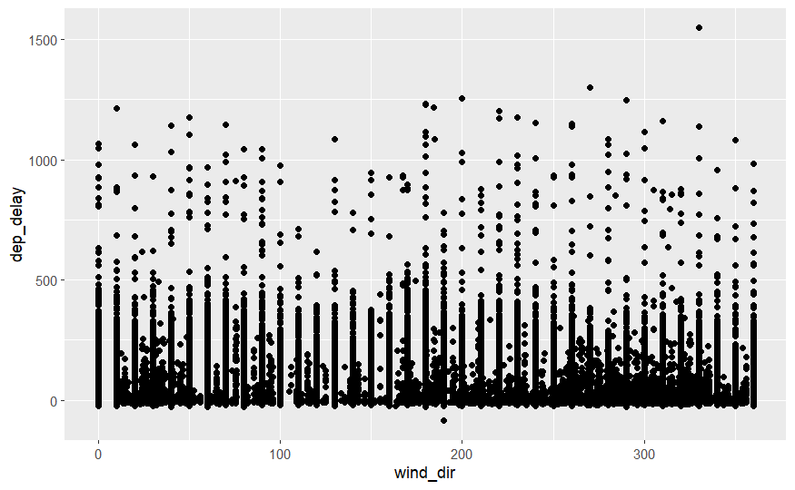

```r
tight_flights_weather %>%
  ggplot()+
  aes(x = wind_dir, y = dep_delay)+
  geom_point()
```

I don’t find from this plot a particular incidence of `wind_dir` with the `dep_delay`.